# Tutorial 2 - Micro foundations for macroeconomics

Theo Arvanitopoulos

# Exercises

## Exercise 1

Suppose that the economy produces only two goods: economics textbooks and corn.

a. Draw a representative PPF curve (label everything carefully!).

b. What are the two assumptions (conditions) needed to draw the above graph?

c. On the above graph, illustrate the set of all possible points of production.

d. What is the economic interpretation of points which lie outside the PPF?

e. Suppose we produce at a point which lies on the PPF (we will call it point **A**).

Redraw the PPF curve and point **A** for each of the following (to illustrate how the event changes the PPF):

i. There is a drought

ii. Unemployment arises due to layoffs

iii. One of the many textbook factories burns down

iv. There is a strike

v. A new plow and offset printing technique are developed

## Exercise 2

Suppose an economy is composed of three individuals (A, B, C) all of whom consume a single good (X). The following table shows how much good X will be demanded by each individual in the economy.

| Price per X (GBP) | Individual A (quantity) | Individual B (quantity) | Individual C (quantity) |
| --- | --- | --- | --- |
| 10 | 0 | 1 | 2 |
| 9 | 1 | 1 | 2 |
| 8 | 2 | 1 | 3 |
| 7 | 3 | 1 | 5 |
| 6 | 4 | 1 | 7 |
| 5 | 5 | 1 | 8 |
| 4 | 6 | 1 | 9 |
| 3 | 7 | 1 | 10 |
| 2 | 8 | 1 | 11 |
| 1 | 9 | 1 | 11 |

a. Using the above information, draw each person’s demand curve for good X.

b. Draw the aggregate demand curve for good X in this economy.

Suppose the industry for good X has the following supply schedule:

| Price per X (GBP) | Quantity |
| --- | --- |
| 10 | 25 |
| 9 | 24 |
| 8 | 21 |
| 7 | 18 |
| 6 | 16 |
| 5 | 14 |
| 4 | 11 |
| 3 | 7 |
| 2 | 2 |
| 1 | 0 |

c. What is the equilibrium price and quantity for X? At this equilibrium, what is the producer’s revenue?

f. Suppose the demand for X increases so that at each price, individuals A and C want to buy two more units (each) of good X, and the demand for individual B is unchanged. What happens to equilibrium price, quantity and revenue (assume that the government does not set the price)? Why has the quantity sold not increased by four units?

# Multiple-choice questions

## MCQ 1

*MCQs 1–2 refer to the following graph.*

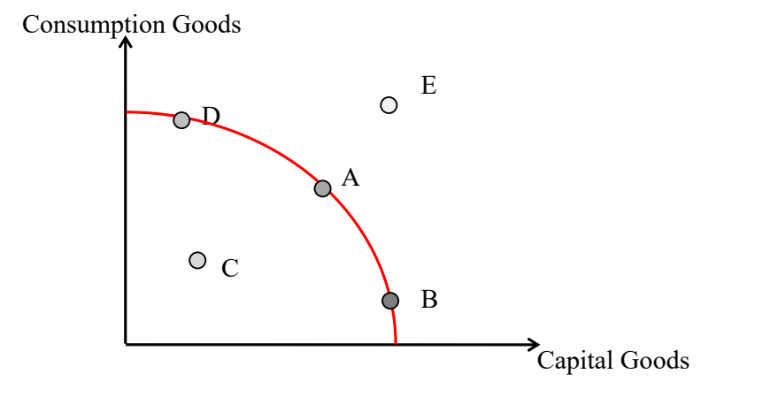

Original diagram

Which point indicates that resources are **not** fully utilized?

a. A

b. B

c. C

d. D

## MCQ 2

*Refer to the graph in MCQ 1.*

Moving from point *D* to point *A* requires

a. technological change.

b. a decrease in employment.

c. reducing the output of consumption goods in order to increase the output of capital goods.

d. capital accumulation.

## MCQ 3

Which of the following is likely to result in a shift in the supply curve for dresses?

a. an increase in equilibrium price

b. a reduction in tariffs that allows dress manufacturers to import cotton cloth at cheaper prices than before.

c. a decrease in dress prices.

d. an increase in population.

## MCQ 4

Assume dresses are a normal good. Which of the following is likely to result in a shift in the demand curve for dresses?

a. an increase in consumer income.

b. a reduction in tariffs that allows dress manufacturers to import cotton cloth at cheaper prices than before.

c. an increase in dress prices.

d. the development of new machines that dramatically increase the productivity of dressmakers.